# Bike Share Analysis Case Study

Nicole Bow

2022-02-08

## Introduction

The following case study is an analysis of bike trip data from the past year. Different statistics will be looked at including trip duration, number of trips, and membership.

The analysis follows the different phases of the data analysis process which you can find in the outline below:

- Objective
- Data Preparation
- Analysis
- Discussion
- Recommendations
- Conclusion

### Objective

The purpose of this analysis is to help a bike share company figure out how to increase their yearly membership. Below is a short description of the company we’re working with:

> *Company name:* Cyclistic

> *Description:* Bikeshare company, founded in 2016

> *Location:* Chicago, IL (USA)

> *Other stats:*
> - 5,824 bicycles registered
> - 4 different bike types (traditional, reclining, hand tricycles, cargo)
> - 692 docking stations
> - 3 different pricing plans (single-ride pass, full-day pass, annual membership)

Our business task is to:

> **figure out the differences between casual riders and annual members** of Cyclistic in order to help them come up with some marketing strategies.

Our key stakeholders are:

> - the *Director of Marketing*
> - the *Executive Team*. *We can also move a step further and consider the *Marketing Team* our secondary stakeholders.*

## Data Wrangling

Before we get started on the data, we need to ensure we have the correct packages running to be able to conduct the analysis. The packages used throughout the case study are:

- `data.table`: *helps with faster importing and writing of csv files*
- `tidyverse`: *helps with data wrangling, transformation and visualisation*
- `lubridate`: *helps with date parsing and time-date calculations*
- `skimr`: *helps with summary statistics*
- `janitor`: *helps with data cleaning*
- `ggplot2`: *helps with visualisations*

We’ll start by uploading each of the 12 data sets.

```r
df13 <- fread("TripData_2022_05.csv")
```

```
##             ride_id rideable_type          started_at            ended_at
## 1: EC2DE40644C6B0F4  classic_bike 2022-05-23 23:06:58 2022-05-23 23:40:19
## 2: 1C31AD03897EE385  classic_bike 2022-05-11 08:53:28 2022-05-11 09:31:22
## 3: 1542FBEC830415CF  classic_bike 2022-05-26 18:36:28 2022-05-26 18:58:18
## 4: 6FF59852924528F8  classic_bike 2022-05-10 07:30:07 2022-05-10 07:38:49
## 5: 483C52CAAE12E3AC  classic_bike 2022-05-10 17:31:56 2022-05-10 17:36:57
## 6: C0A3AA5A614DCE01  classic_bike 2022-05-04 14:48:55 2022-05-04 14:56:04
##                   start_station_name start_station_id
## 1:            Wabash Ave & Grand Ave     TA1307000117
## 2: DuSable Lake Shore Dr & Monroe St            13300
## 3:           Clinton St & Madison St     TA1305000032
## 4:           Clinton St & Madison St     TA1305000032
## 5:           Clinton St & Madison St     TA1305000032
## 6:           Carpenter St & Huron St            13196
##                 end_station_name end_station_id start_lat start_lng  end_lat
## 1:        Halsted St & Roscoe St   TA1309000025  41.89147 -87.62676 41.94367
## 2:   Field Blvd & South Water St          15534  41.88096 -87.61674 41.88635
## 3:       Wood St & Milwaukee Ave          13221  41.88224 -87.64107 41.90765
## 4:        Clark St & Randolph St   TA1305000030  41.88224 -87.64107 41.88458
## 5:           Morgan St & Lake St   TA1306000015  41.88224 -87.64107 41.88578
## 6: Sangamon St & Washington Blvd          13409  41.89456 -87.65345 41.88316
##      end_lng member_casual
## 1: -87.64895        member
## 2: -87.61752        member
## 3: -87.67255        member
## 4: -87.63189        member
## 5: -87.65102        member
## 6: -87.65110        member
```

Each of the data sets are csv files with different metrics such as the length and date of the bike rides, the bike stations, and the rider’s ID. After looking through the data, these are the following issues noted that need to be cleaned:

1. Between `2021_05` and `2021_11` there are very few station details recorded (`name` and `id`).
2. Starting `2021_12` the `stations names` are included, but `station ids` remain inconsistent throughout the data.

It would make more sense to sort the issues highlighted above when working with a merged data frame. To do this, we need to look over each data frame to ensure the column names are similar:

```r
colnames(df13)
```

```
##  [1] "ride_id"            "rideable_type"      "started_at"
##  [4] "ended_at"           "start_station_name" "start_station_id"
##  [7] "end_station_name"   "end_station_id"     "start_lat"
## [10] "start_lng"          "end_lat"            "end_lng"
## [13] "member_casual"
```

All the data frames have similar column names. We can also check the data types and have an overview of the columns to confirm if there are any inconsistencies:

```r
str(df13)
```

```
## Classes 'data.table' and 'data.frame':   634858 obs. of  13 variables:
##  $ ride_id           : chr  "EC2DE40644C6B0F4" "1C31AD03897EE385" "1542FBEC830415CF" "6FF59852924528F8" ...
##  $ rideable_type     : chr  "classic_bike" "classic_bike" "classic_bike" "classic_bike" ...
##  $ started_at        : POSIXct, format: "2022-05-23 23:06:58" "2022-05-11 08:53:28" ...
##  $ ended_at          : POSIXct, format: "2022-05-23 23:40:19" "2022-05-11 09:31:22" ...
##  $ start_station_name: chr  "Wabash Ave & Grand Ave" "DuSable Lake Shore Dr & Monroe St" "Clinton St & Madison St" "Clinton St & Madison St" ...
##  $ start_station_id  : chr  "TA1307000117" "13300" "TA1305000032" "TA1305000032" ...
##  $ end_station_name  : chr  "Halsted St & Roscoe St" "Field Blvd & South Water St" "Wood St & Milwaukee Ave" "Clark St & Randolph St" ...
##  $ end_station_id    : chr  "TA1309000025" "15534" "13221" "TA1305000030" ...
##  $ start_lat         : num  41.9 41.9 41.9 41.9 41.9 ...
##  $ start_lng         : num  -87.6 -87.6 -87.6 -87.6 -87.6 ...
##  $ end_lat           : num  41.9 41.9 41.9 41.9 41.9 ...
##  $ end_lng           : num  -87.6 -87.6 -87.7 -87.6 -87.7 ...
##  $ member_casual     : chr  "member" "member" "member" "member" ...
##  - attr(*, ".internal.selfref")=<externalptr>
```

After confirming that all the data types and column names are consistent, we can go ahead and merge all the data frames.

### Data Cleaning

Because the data cleaning process might involve the removal of some data, we will go ahead and save a copy of the newly created data frame to the local machine, as well as create a copy of the data to work with moving forward.

```r
head(trip_data)
```

```
##    V1          ride_id rideable_type          started_at            ended_at
## 1:  1 C809ED75D6160B2A electric_bike 2021-05-30 11:58:15 2021-05-30 12:10:39
## 2:  2 DD59FDCE0ACACAF3 electric_bike 2021-05-30 11:29:14 2021-05-30 12:14:09
## 3:  3 0AB83CB88C43EFC2 electric_bike 2021-05-30 14:24:01 2021-05-30 14:25:13
## 4:  4 7881AC6D39110C60 electric_bike 2021-05-30 14:25:51 2021-05-30 14:41:04
## 5:  5 853FA701B4582BAF electric_bike 2021-05-30 18:15:39 2021-05-30 18:22:32
## 6:  6 F5E63DFD96B2A737 electric_bike 2021-05-30 11:33:41 2021-05-30 11:57:17
##    start_station_name start_station_id end_station_name end_station_id
## 1:
## 2:
## 3:
## 4:
## 5:
## 6:
##    start_lat start_lng end_lat end_lng member_casual
## 1:     41.90    -87.63   41.89  -87.61        casual
## 2:     41.88    -87.62   41.79  -87.58        casual
## 3:     41.92    -87.70   41.92  -87.70        casual
## 4:     41.92    -87.70   41.94  -87.69        casual
## 5:     41.94    -87.69   41.94  -87.70        casual
## 6:     41.88    -87.63   41.89  -87.62        casual
```

We’ll remove the inconsistent columns like the station names and the station coordinates since a lot of data frames had many missing values:

```r
trip_data <- trip_data %>%
  select(ride_id, rideable_type, started_at, ended_at, member_casual)
head(trip_data)
```

```
##             ride_id rideable_type          started_at            ended_at
## 1: C809ED75D6160B2A electric_bike 2021-05-30 11:58:15 2021-05-30 12:10:39
## 2: DD59FDCE0ACACAF3 electric_bike 2021-05-30 11:29:14 2021-05-30 12:14:09
## 3: 0AB83CB88C43EFC2 electric_bike 2021-05-30 14:24:01 2021-05-30 14:25:13
## 4: 7881AC6D39110C60 electric_bike 2021-05-30 14:25:51 2021-05-30 14:41:04
## 5: 853FA701B4582BAF electric_bike 2021-05-30 18:15:39 2021-05-30 18:22:32
## 6: F5E63DFD96B2A737 electric_bike 2021-05-30 11:33:41 2021-05-30 11:57:17
##    member_casual
## 1:        casual
## 2:        casual
## 3:        casual
## 4:        casual
## 5:        casual
## 6:        casual
```

We’ll rename the columns to make the names shorter. This is not a necessary step, but it makes the cleaning steps and analysis easier:

```r
trip_data <- trip_data %>%
  rename(id=ride_id) %>%
  rename(start=started_at) %>%
  rename(end=ended_at) %>%
  rename(membership=member_casual) %>%
  rename(bike=rideable_type)
colnames(trip_data)
```

```
## [1] "id"         "bike"       "start"      "end"        "membership"
```

Because we have a date column and we could generate some important insights from this, we will go ahead and create different columns representing the day, month and year as well as the actual day of the week. We will also change the data type of each of these columns:

```r
str(trip_data)
```

```
## Classes 'data.table' and 'data.frame':   6392409 obs. of  10 variables:
##  $ id         : chr  "C809ED75D6160B2A" "DD59FDCE0ACACAF3" "0AB83CB88C43EFC2" "7881AC6D39110C60" ...
##  $ bike       : chr  "electric_bike" "electric_bike" "electric_bike" "electric_bike" ...
##  $ start      : POSIXct, format: "2021-05-30 11:58:15" "2021-05-30 11:29:14" ...
##  $ end        : POSIXct, format: "2021-05-30 12:10:39" "2021-05-30 12:14:09" ...
##  $ membership : chr  "casual" "casual" "casual" "casual" ...
##  $ date       : Date, format: "2021-05-30" "2021-05-30" ...
##  $ month      : chr  "05" "05" "05" "05" ...
##  $ day        : chr  "30" "30" "30" "30" ...
##  $ year       : chr  "2021" "2021" "2021" "2021" ...
##  $ day_of_week: Ord.factor w/ 7 levels "Sunday"<"Monday"<..: 1 1 1 1 1 1 1 4 4 3 ...
##  - attr(*, ".internal.selfref")=<externalptr>
```

Next, we’re going to add another column called `duration` that represents the length of the ride.We’re going to manually calculate this using the `start` and `end` columns. We will also convert this column data type from the default which would be a `factor` data type to `numeric` so that we can perform calculations on it later:

```r
str(trip_data)
```

```
## Classes 'data.table' and 'data.frame':   6392409 obs. of  11 variables:
##  $ id         : chr  "C809ED75D6160B2A" "DD59FDCE0ACACAF3" "0AB83CB88C43EFC2" "7881AC6D39110C60" ...
##  $ bike       : chr  "electric_bike" "electric_bike" "electric_bike" "electric_bike" ...
##  $ start      : POSIXct, format: "2021-05-30 11:58:15" "2021-05-30 11:29:14" ...
##  $ end        : POSIXct, format: "2021-05-30 12:10:39" "2021-05-30 12:14:09" ...
##  $ membership : chr  "casual" "casual" "casual" "casual" ...
##  $ date       : Date, format: "2021-05-30" "2021-05-30" ...
##  $ month      : chr  "05" "05" "05" "05" ...
##  $ day        : chr  "30" "30" "30" "30" ...
##  $ year       : chr  "2021" "2021" "2021" "2021" ...
##  $ day_of_week: Ord.factor w/ 7 levels "Sunday"<"Monday"<..: 1 1 1 1 1 1 1 4 4 3 ...
##  $ duration   : num  744 2695 72 913 413 ...
##  - attr(*, ".internal.selfref")=<externalptr>
```

Next, we’ll remove all the missing values:

Finally, we’ll save a copy of the cleaned data frame in case anything goes wrong in the analysis and we need to revert to it:

## Analysis

In this section, we’ll perform a few calculations and have a few visualisations to get some insights on the different trends and relationships in the data.

#### Membership

Given that this is supposed to be our primary focus, we can go ahead and count how many trips were had by both casual and member riders we have in total:

```r
nrow(trips[trips$membership == "casual"])
```

```
## [1] 2816773
```

```r
nrow(trips[trips$membership == "member"])
```

```
## [1] 3575636
```

> *Observation:*

> From the above we can see that there are more member riders ($3,575,636$) than casual riders ($2,816,773$).

#### Duration

Next, we are going to get the descriptive statistics for the duration:

```r
summary(trips$duration)
```

```
##    Min. 1st Qu.  Median    Mean 3rd Qu.    Max.
##   -3482     386     691    1268    1259 3356649
```

We can see that the minimum trip duration is `-3482 seconds` which is not accurate, because that means the end time was before the start time. Bearing in mind that data cleaning is an iterative process, we can go ahead and try and see how many trips have a duration of 0 and less to ensure that we are working with accurate data:

```r
short_trips <- filter(trips, duration <= 0)
dim(short_trips)
```

```
## [1] 700  11
```

Given that there are $700$ rides with a duration of zero, we can go ahead and create a new data frame that does not include trips that are less than 60 seconds(1 minute).

We can check the summary stats once again, bearing in mind that the minimum will ride will be at least 60 seconds:

```
##    Min. 1st Qu.  Median    Mean 3rd Qu.    Max.
##      61     399     703    1289    1274 3356649
```

We can also plot that on a simple histogram and look at the distribution of duration:

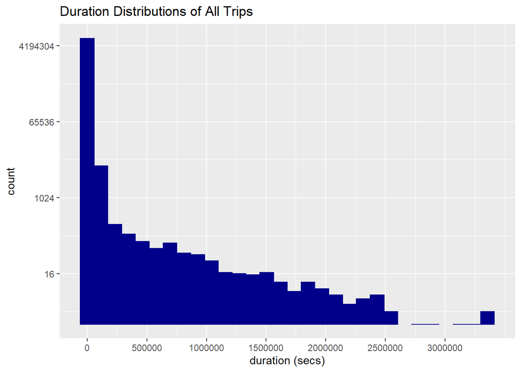

From the above diagram, we can see that there were still outliers in the data set. We can go ahead and create a new data frame by removing all trips that are more than $1,000,000$ seconds since these are typically less than 16 for each bin in the diagram. We will also counter check the summary stats once again and create a new plot after:

```
##    Min. 1st Qu.  Median    Mean 3rd Qu.    Max.
##      61     399     703    1251    1274  998375
```

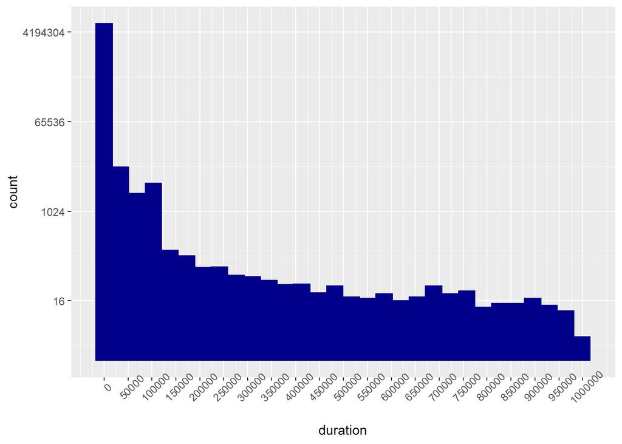

```
## $x
## [1] "duration (secs)"
##
## $title
## [1] "Duration Distributions of All Trips (Outliers removed)"
##
## attr(,"class")
## [1] "labels"
```

> *Observations:*

> From the first distribution, we can see that most trips are less than $125,000$ seconds (1.4days). There are also pockets of trips that are much longer than $1,000,000$ seconds (11.5 days). From the second distribution, we can see that most trips are less than $10,000$ seconds (2.7 hours).

#### Duration Vs. Membership

From the previous section, we saw that there were still outliers in the data set. We can go ahead and remove all trips that are more than $1,000,000$ seconds since these are typically less than 16 for each bin in the diagram. We’ll also counter check the summary stats once again:

We can also compute the same statistics and compare the `casual` vs `member` membership types. For clarification purposes:

1. Casual riders constitute of people who subscribe for single and day passes.
2. Members are people who have paid for annual passes.

```
##   trips$membership trips$duration
## 1           casual      1817.2561
## 2           member       803.9292
```

```
##   trips$membership trips$duration
## 1           casual            947
## 2           member            563
```

```
##   trips$membership trips$duration
## 1           casual         998375
## 2           member          93594
```

```
##   trips$membership trips$duration
## 1           casual             61
## 2           member             61
```

Out of curiosity, it would be good to know the number of trips that were more than a million seconds in duration. We’ll use the first data frame to figure this out:

[output not shown]

[output cut: 291 more lines]

```
## # A tibble: 1 × 2
##   membership num_rides
##   <chr>          <int>
## 1 casual           152
```

We can go ahead and plot the average duration for the two membership types on a bar chart since we’re working with categorical and continuous data:

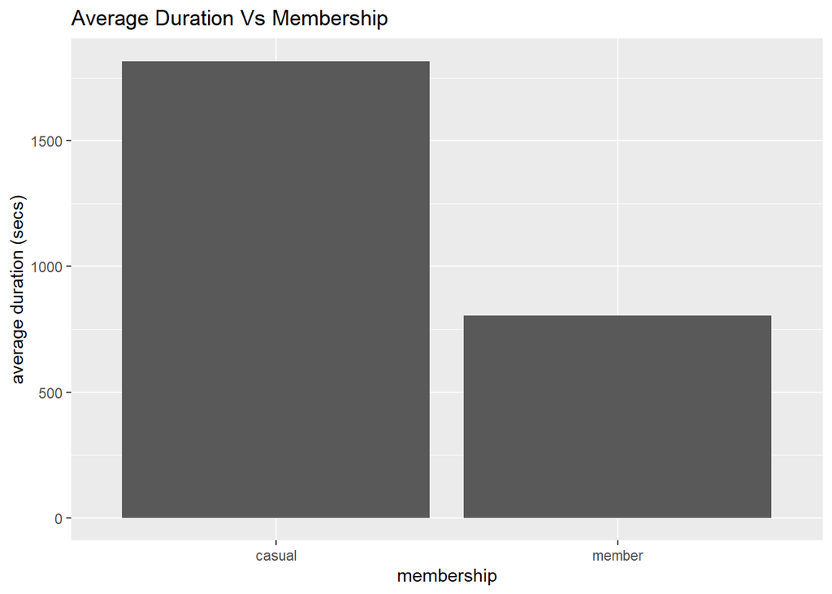

> *Observations:*

> From the above we can see that casual riders have higher trip durations than members across all categories except the minimum, which is similar for both. Particularly focusing on the mean, causal riders have a mean trip duration of $1,817$ seconds (30 minutes) while members have a mean trip duration of $803$ seconds (13 minutes).

> All rides that were above $1,000,000$ seconds (11.5 days) can be attributed to casual riders.

#### Duration Vs. Membership Vs. Day of Week

We’ll need to look at the trip durations’ descriptive statistics by day and membership in order to get some additional insights:

```
##    trips$membership trips$day_of_week trips$duration
## 1            casual            Sunday      2113.1611
## 2            member            Sunday       917.2687
## 3            casual            Monday      1861.7490
## 4            member            Monday       781.0172
## 5            casual           Tuesday      1574.9553
## 6            member           Tuesday       751.1248
## 7            casual         Wednesday      1572.2975
## 8            member         Wednesday       757.0197
## 9            casual          Thursday      1619.4891
## 10           member          Thursday       762.9472
## 11           casual            Friday      1684.7025
## 12           member            Friday       786.0857
## 13           casual          Saturday      1972.0363
## 14           member          Saturday       903.6005
```

We can go ahead and create a clustered bar chart showing the average ride duration against the day of the week, and grouped by membership:

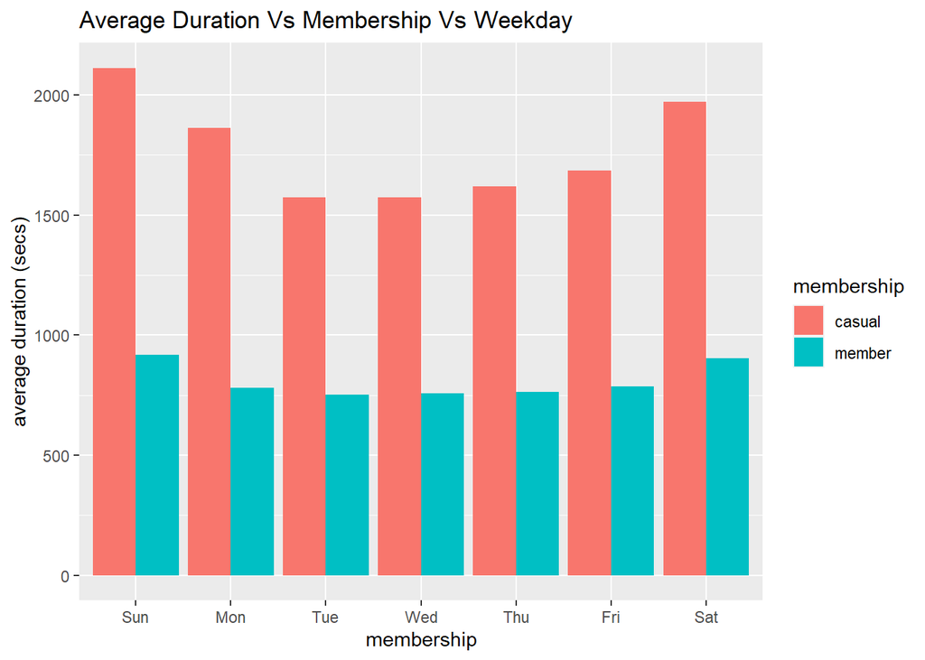

> *Observations:*

> Casual riders have higher average trips durations than members on all days of the week.

#### Duration Vs. Number of Rides Vs. Membership Vs. Weekday

Given the above observations, it would be interesting to compare the number of rides as well as the average duration during the different days of the week:

```
## # A tibble: 14 × 4
## # Groups:   membership [2]
##    membership weekday num_rides avg_duration
##    <chr>      <ord>       <int>        <dbl>
##  1 casual     Sun        524351        2113.
##  2 casual     Mon        331478        1862.
##  3 casual     Tue        301087        1575.
##  4 casual     Wed        304447        1572.
##  5 casual     Thu        326720        1619.
##  6 casual     Fri        384700        1685.
##  7 casual     Sat        602350        1972.
##  8 member     Sun        428246         917.
##  9 member     Mon        498777         781.
## 10 member     Tue        548833         751.
## 11 member     Wed        542602         757.
## 12 member     Thu        528407         763.
## 13 member     Fri        486672         786.
## 14 member     Sat        478212         904.
```

The above data, with a focus on number of rides, will be plotted have a visual representation of the data:

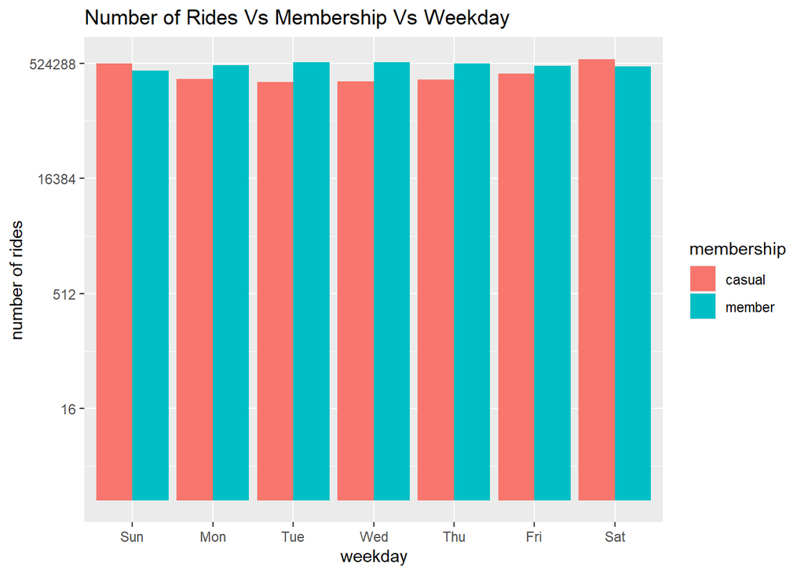

> *Observations:*

> Based on the number of trips:
> - Member riders overall take more trips than casual riders on all days of the week apart from Saturdays and Sundays.
> - **Weekends** (Friday, Saturday and Sunday) are the most popular days for casual riders.
> - **Mid-week** (Tuesday, Wednesday, amd Thursday) are the most popular days for members.

#### Duration vs Month Vs Membership

We’ll first start by creating a year-month column given that there are some months that are represented in both 2021 and 2022:

```r
str(trips)
```

```
## Classes 'data.table' and 'data.frame':   6286882 obs. of  12 variables:
##  $ id         : chr  "C809ED75D6160B2A" "DD59FDCE0ACACAF3" "0AB83CB88C43EFC2" "7881AC6D39110C60" ...
##  $ bike       : chr  "electric_bike" "electric_bike" "electric_bike" "electric_bike" ...
##  $ start      : POSIXct, format: "2021-05-30 11:58:15" "2021-05-30 11:29:14" ...
##  $ end        : POSIXct, format: "2021-05-30 12:10:39" "2021-05-30 12:14:09" ...
##  $ membership : chr  "casual" "casual" "casual" "casual" ...
##  $ date       : Date, format: "2021-05-30" "2021-05-30" ...
##  $ month      : chr  "05" "05" "05" "05" ...
##  $ day        : chr  "30" "30" "30" "30" ...
##  $ year       : chr  "2021" "2021" "2021" "2021" ...
##  $ day_of_week: Ord.factor w/ 7 levels "Sunday"<"Monday"<..: 1 1 1 1 1 1 1 4 4 3 ...
##  $ duration   : num  744 2695 72 913 413 ...
##  $ year_month : Ord.factor w/ 13 levels "May 21"<"Jun 21"<..: 1 1 1 1 1 1 1 1 1 1 ...
##  - attr(*, ".internal.selfref")=<externalptr>
```

Now we can go ahead and calculate the summary stats on the average duration and number of trips for each month in the data set:

```
## # A tibble: 26 × 4
## # Groups:   membership [2]
##    membership year_month num_rides avg_duration
##    <chr>      <ord>          <int>        <dbl>
##  1 member     Dec 21        174838         671.
##  2 member     Nov 21        248646         690.
##  3 member     Feb 22         92046         700.
##  4 member     Apr 22        239800         704.
##  5 member     Mar 22        190561         731.
##  6 member     Jan 22         83752         731.
##  7 member     Oct 21        367371         763.
##  8 member     May 22        347252         818.
##  9 member     Sep 21        385900         837.
## 10 member     Aug 21        385366         860.
## # … with 16 more rows
```

Now we’ll create a simple column chart to represent the average duration of the trips per month and separate them by membership:

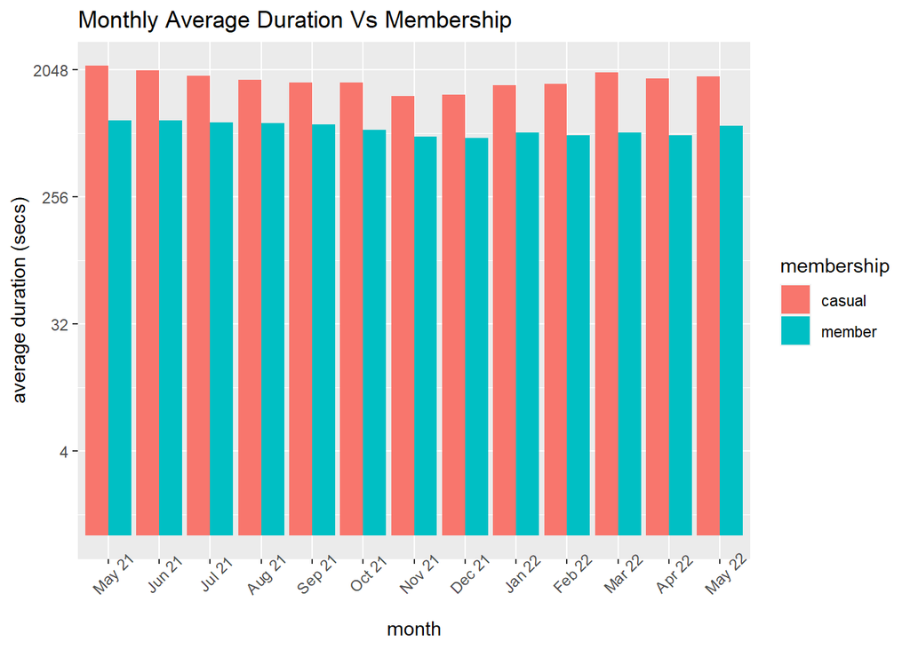

We’ll also create another column chart representing the number of trips per month and separate them by membership:

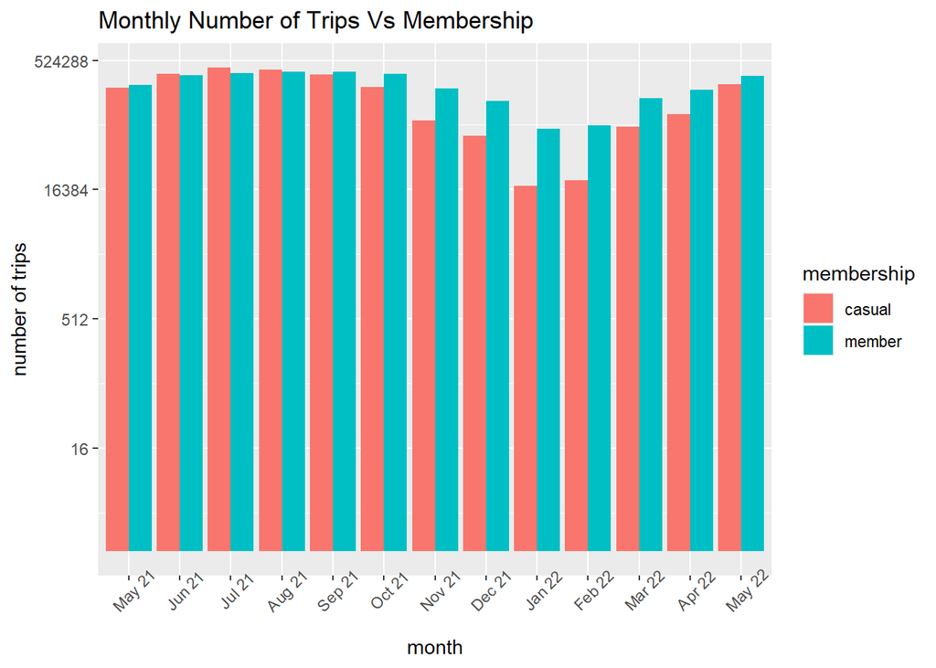

> *Observations:*

> Member riders have higher trips numbers throughout the whole year excpet in Jun21, Jul21 and Aug21, where casual riders have the most trips.

> Casual riders have higher trip durations throughout the whole year.

> `Jul21- Casual Riders`, `Aug21- Casual Riders` and `Sep21- Member Riders` are the top three months with the highest number of trips respectively, with July(21) and August(21) having over 400,000 trips. These segements were for the casual rider group, with the expeption of September(21) which was for the member riders.

> `Jan22- Casual Riders`, `Feb22- Casual Riders` and `Dec21- Casual Riders` have the lowest number of trips respectively with January(22) and February(22) having less than 50,000 trips. This segment was for the causal rider group.

> `May21- Casual Riders`, `Jun21- Casual Riders` and `Mar22- Casual Riders` are the months and riders with the highest average duration with May(21) and June(21) having over 2,000 seconds(33 minutes).

> `Dec21- Member Riders`,`Nov21- Member Riders` and `Feb22- Member Riders` are the months and riders with the lowest average trip durations, all having less than 700 seconds(11 minutes).

## Discussion

From the analysis above, there are a few insights worth diving into further. They are discussed below in more detail:

- **Membership: There are more member riders than casual riders**

Member riders outnumber casual riders by $758,863$. This could be the primary reason why annual memberships are seen as more profitable than full day or single-ride passes.

- **Duration: Casual riders have higher trip durations than member riders**

Across all the descriptive statistics (mean, max and median), casual riders have longer trips than member riders. Based on the section above, it could mean that the flexibility in the pricing plan is what attracts casual riders since all trips that were more than 11.5 days can be attributed to casual riders.

- **Day of the week: Weekends for casual riders, Mid-week for members**

- **Month: Member riders have consistently more trips during the year**

### Recommendations

1. *Review the revenue brought in by single, full-day and annual memberships.*

Given that summer seems to e the time casual riders peak, rather than trying to converting them to annual members, it could make more sense increasing the price of the single and full day passes, or even creating a weekly/monthly/trimester plan that would include the 3 month spike. This could add more revenue options while still ensuring the selling point of pricing flexibility is maintained.

2. *Improving customer information databases.*

It’s interesting that casual trips increase during certain months of the year and days of the week. It would be interesting to see if majority of members are people who work and causal members are students or tourists. This could explain why annual memberships may not be workable for them and may help in devising more affordable, yet profitable pricing plans. It may also help in anticipating spikes in bike demand.

3. *Add geo-tagging features on the bikes.*

This may seem like a big investment, but having a map of the common routes taken by casual and member riders can give an indication of the different routes taken and possibly help in determining if the longer trips are related to things like periodical biking expeditions (weekly, monthly or annually). A good avenue for revenue may be renting out the bikes to the arrangers of the biking competition, or advertising to get more regular customers who are into biking but may either not want to use their personal bikes or may not be able to travel with their bikes for the expeditions.It could also help figure out if member riders are people who live within the area and are simply using the bikes as alternative transport, hence the numerous mid-week trips with short durations.

## Conclusion

In conclusion, we’ve seen that member riders typically have more trips than causal riders and are active during the week and year-round. Casual riders tend to take longer trips, and are mostly active during summer and during the weekends.

Some recommendations include reviewing pricing plans to determine if flexibility can be maintained while still achieving profitability, improving customer databases and considering investments such as geo-tagging to discover popular routes among the memberships.